# На точак: дополнета анализа од билтени на МВР за сообраќајните незгоди во кои страдаат велосипедисти

## Вовед

На крајот на март 2018 година иницијативата На Точак објави [статистики](https://natochak.blogspot.mk/2018/03/blog-post_1.html) за сообраќајните незгоди во Македонија што вклучуваат велосипедисти. Оваа презентација оди чекор понатаму со тоа што додава повеќе податоци за анализа и можеби отркива некои трендови (patterns?) по кои што се случуваат незгодите. Презентацијата подолу се фокусира само на сообраќајни незгоди, пред се автомобил/велосипед. Други инциденти, како што е на пример напад од куче, не се вклучени.

### Зголемувањето на бројот на податоци

Оригиналнииот датасет од НаТочак имаше седум променливи. Но, билтените на МВР кријат уште променливи во нив. Затоа во новиот датасет [достапен на github](https://github.com/novica/natochak/) додадовме уште осум (или девет) променливи. Некои од нив имаат многу малку податоци, но сепак ја подобруваат сликата за податоците со кои што (може) да се располага. На пример, во сите билтени од МВР многу малку се спомнува дали возачот на моторното возило или велосипедот бил под дејство на алкохол (само три пати). Не знаеме дали ова се должи на непотполно објавени информации во веб-билтените или пак на навистина низок број на возачи или велосипедисти под дејство на алкохол.

Некои променливи ги променивме. На пример, во промелнивата за патот каде се случила незгодата додадовме „отворен пат“, покрај „градски“ и „селски“. Понатаму, за побрза работа во статистичката средина `R` направивме и некои трансформации за месеците во кои се случени незгодите како и водовите возила кои биле вклучени во незгодите.

### Идеи за понатаму

Она што недостига, а што може да се додаде (со малку повеќе работа) се податоци за тоа дали на урбаните места каде што се случила незгода има тротоар или друга површина за велосипедска патека и дали е таа слободна (без паркирани возила). Слични податоци би можеле да се додадат и во однос на регионалните патишта каде што се случувале незгоди. Претпоставката е дека достапноста на велосипедска површина би го намалила бројот на незгодите, па од тие причини, ваква променлива би додала многу во насока на безбедноста на сите вклучени во сообраќајот.

Други компоненти од интерес се некаква проценка за фрекфенцијата на моторни и велосипедски сообраќај на делниците и опкружувањето на делниците каде се случиле незгодите. Со вакви податоци би можеле да провериме дали патишта на кои од разни причини има повеќе велосипедисти–можеби затоа што се блиску до училишта, игралишта, паркови, или пазари–се повеќе ризични за сообраќајни незгоди. Особено имајќи во предвид, како што ќе видиме подоле, дека лица од најмладите и најстарите старосни групи почесто возат точак и почесто се вклучени во сообраќајни незгоди.

## Преглед на сообраќајни незгодии по возраст на велосипедист и час кога се случила, групирани по исход и вид на пат

Генералниот визуелен приказ на жртвите во сообраќајните незгоди изгледа отрпилика вака:

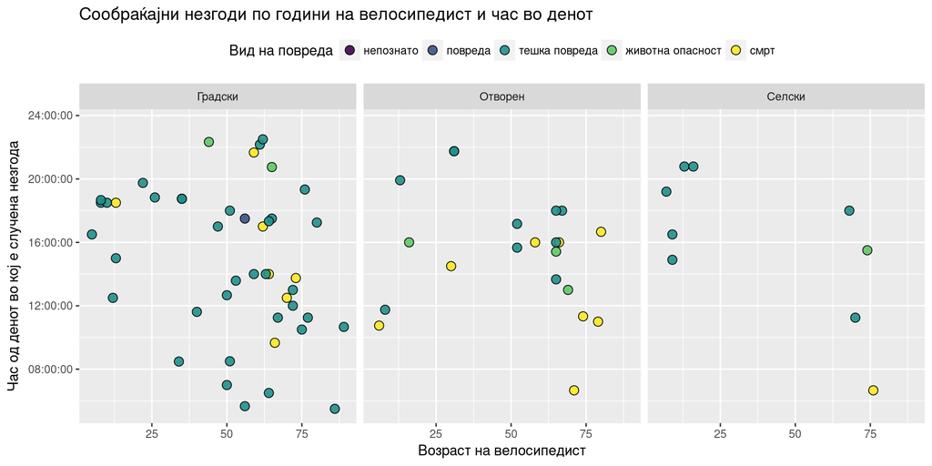

Може да се заклучи дека, веројатно, најбезбедно е да возите точак ако имате од 25 до 50 години. Иако, можеби најниското учество на оваа старосна група се должи на тоа дека таа можеби најмалку вози велосипед. Истовремено, најбезбедно е во раните утрински часови (до 10 наутро). Ова делува чудно: во утринскиот шпиц нема толку сообраќајни незгоди колку во попладневниот. Можеби ова се должи на заморот што по работниот ден се јавува кај сите учесници во сообраќајот.

## Каде се случуваат сообраќајните незгоди?

Значаен број на сообраќајни незгоди во кои страдаат велосипедисти се случуваат на отворен пат. Ова отвора прашање за безбедност на отворените патишта: дали отворените патишта имаат простор на кој велосипеди можат да возат, или пак за сообраќајните незгоди се виновни возачите што возат по неприлагодена брзина?

Во урбаните средини пак односот помеѓу незгоди на крстосница или не е 50:50. Дополнително би требало да се истражи дали на крстосниците има семафори, и дали всушност незгодите се имаат случено поради непочитување на сигнализацијата.

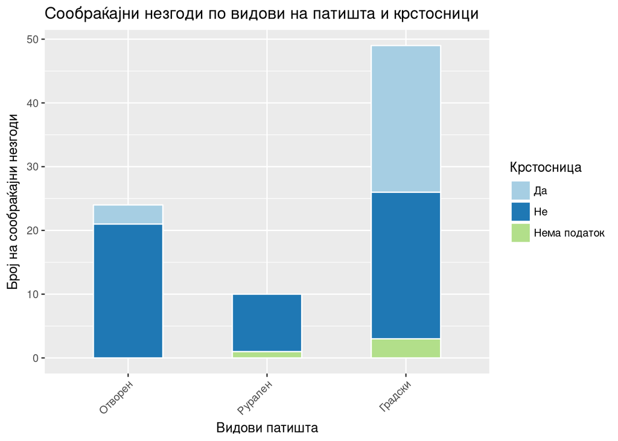

## Отворените патишата се посмртоносни од урбаните средини

Прашањето за неприлагодени брзини на возачите добива на значење и од податоците што велат дека отворените патишта се најсмртоносни за велосипедистите. Алтернативно толкување би било дека причината за смрт е долго чекање до медицинска помош на некој отворен пат. За жал податоци за колку време се пренесени повредените во болница нема.

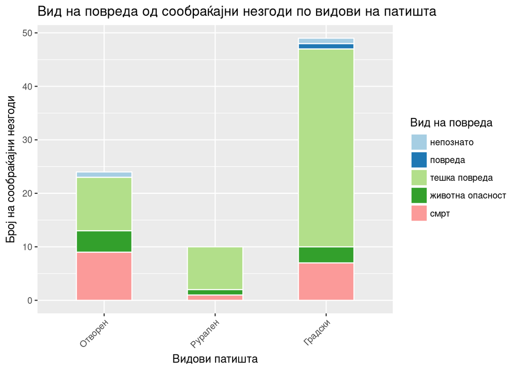

## Сообраќајни незгоди по старосни групи

Дистрибуцијата на велосипедисти по години што настрадале во сообраќајна незгода е бимодална: или тие (млади и стари) најмногу возат, или се најранливи во сообраќајот.

Дистрибуцијата на возачи пак е концентрирана од рани 20т-и до 50-ти години и потоа има остар пад. Загрижувачки е што младите возачи се најчести учесници во сообраќајни незгоди со велосипедисти. Од друга страна остриот пад над 50-тата година може да значи дека луѓето над таа возраст помалку возат автомобил.

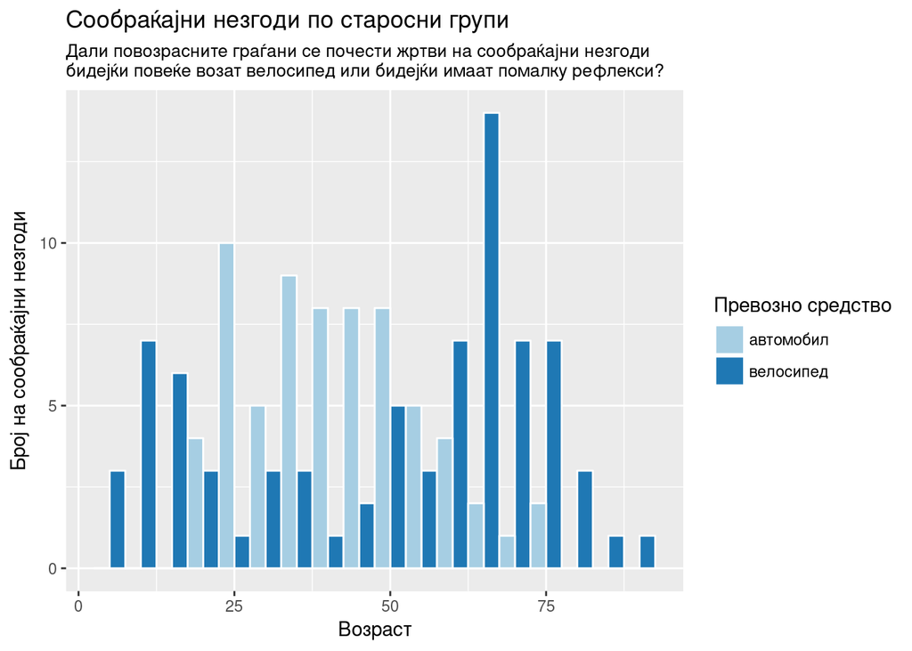

## Повреди од сообраќајни незгоди по старосни групи на велосипедисти

Сообраќајните незгоди завршуваат со смртни последици најмногу кај велосипедистите со над 60-тина години што многу веројатно се должи на нивното севкупно покревко здравје.

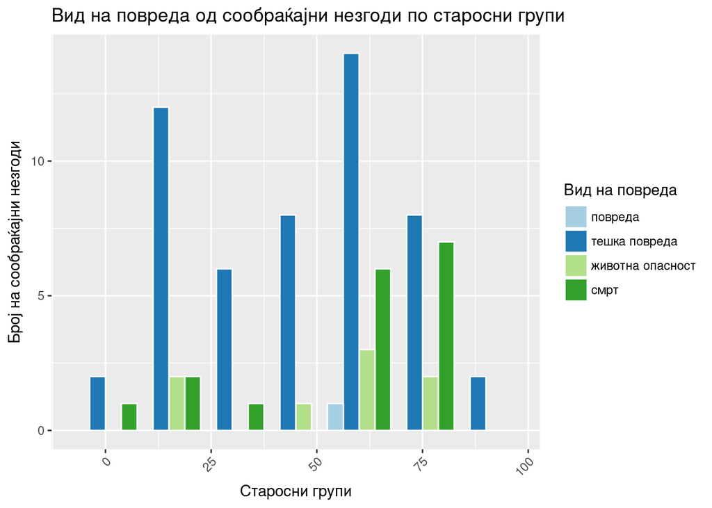

## Сообраќајни незгоди по месеци и вид на повреда на велосипедистите и вид на патишта

Повредите на велосипедистите најмногу се случуваат во летните месеци и забележителен е пораст на незгоди на отворените патишта во летниот период. Ова може да значи дека определена група на граѓани во летниот период користат повеќе велосипед како основно превозно средство, или пак дека отоврените патишта имаат повеќе автомобилски сообраќај поради летувања и слично – што на крај резултира со повеќе сообраќајни незгоди на нив.

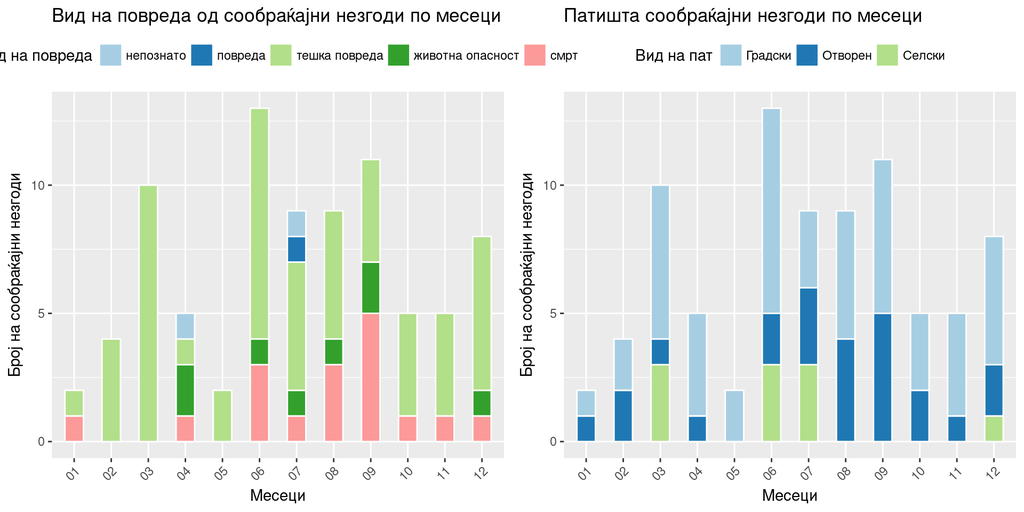

## Сообраќајни незгоди по часови и вид на повреда на велосипедистите и вид на патишта

Споредувањето на сообраќајните незгоди по час во денот и тип на пат укажува дека најголем дел тешки повреди се случуваат во урбаните средини во попладневните часови. Дали ова се должи на заморот кај двете групи возачи по долг работен ден, нервозата во сообраќајните гужви (барем за Скопје?) или нешто трето, останува да се истражува.

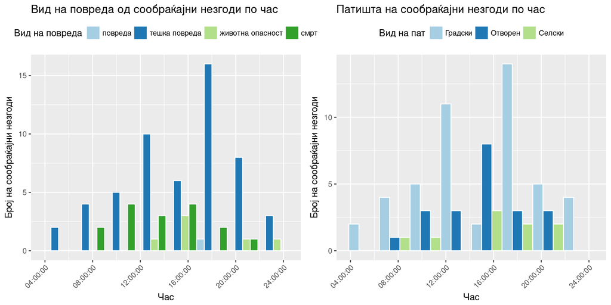

## Географска дистрибуција на сообраќајните незгоди во кои страдале велосипедисти

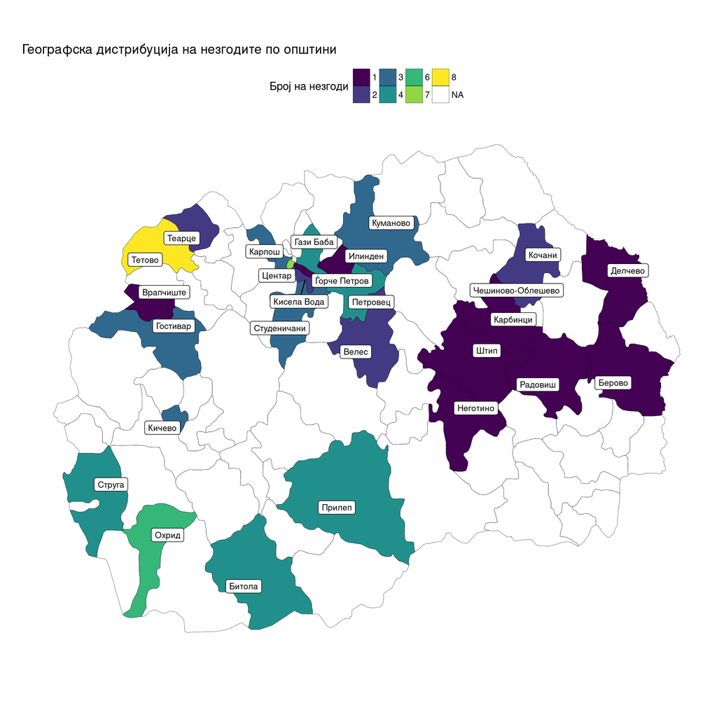